# A little statistis Q1B

```python
import numpy as np
import matplotlib
import matplotlib.pyplot as plt
import scipy
from scipy import stats
```

Integrating the standard normal distribution to find the probability associated with given sigma.

```python
prob1 = stats.norm.cdf(1)
prob2 = stats.norm.cdf(3)
prob3 = 1- stats.norm.cdf(3)

print(prob1)
print(prob2)
print(prob3)
```

```
0.8413447460685429
0.9986501019683699
0.0013498980316301035
```

The probabilities match the cumulative z values. Z = 1 => 0.84134 Z = 3 => 0.99865 Z = -3 => 0.00135

These probabilities are calcualted by integrating the starndard normal distribution from the negative infinity to given sigma value.

# A little statistis Q1C

Calculating the sigma using norm.ppf() and given probaiblity.

```python
sigma1 = stats.norm.ppf(0.8413447460685429)
sigma2 = stats.norm.ppf(0.9986501019683699)
sigma3 = stats.norm.ppf(0.0013498980316301035)

print(sigma1)
print(sigma2)
print(sigma3)
```

```
1.0
2.9999999999999982
-2.9999999999999982
```

Above sigma values are calculated by giving a specific value of probability norm.ppf(). We know from Q1B the correct sigma asoociated with each probability and here I am proving that the sigma values match that values.

# A little statistis Q1D

Meaning of the minus sigma?

We can see in Q1B that norm.cdf() integrates the standard normal distribution from minus infinity to the sigma value given as the parameter. Generally, when we are looking for a probability associated with a specific sigma value, we are looking for a probility to the right of the sigma value, i.e. from that sigma value to positive infinity. So in this case, we will need to calculate the probability using either 1-norm.cdf(positive sigma) or norm.cdf(minus sigma). Since normal distribution is symmetrical, integration the distribution from minus infinity to minius sigma value will return the correct tail-end probability. So depnding on the context, we will need to use positive sigma or negative sigma to get the correct probability.

# A little statistis Q2A: I decided to use an exponential distribution

Here is my plot for the exponential distribution

```
<function matplotlib.pyplot.show(*args, **kw)>
```

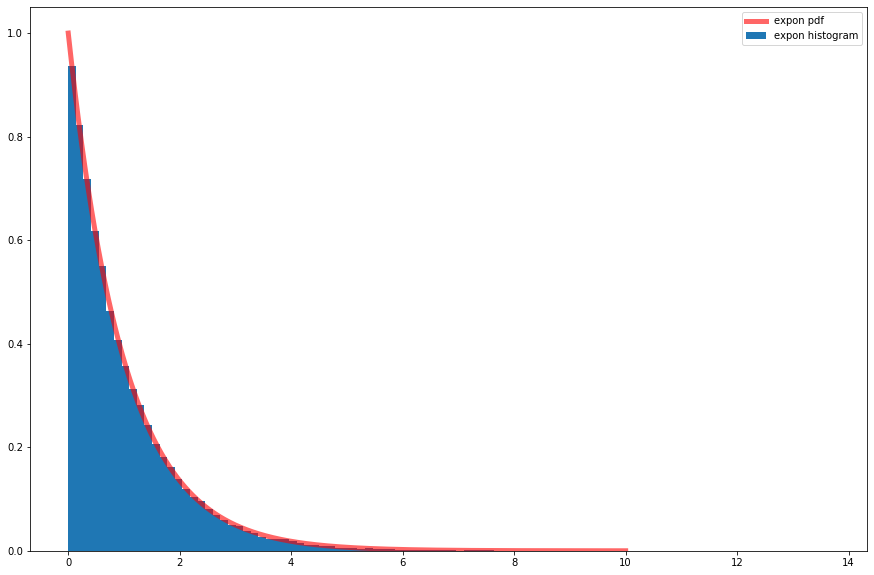

```python
plt.rcParams["figure.figsize"] = (15,10)
fig, ax = plt.subplots(1, 1)

x = np.linspace(0,10,1000);
prob = stats.expon.pdf(x)
ax.plot(x, prob,'r-', lw=5, alpha=0.6, label='expon pdf')
ax.legend()

r = stats.expon.rvs(size=100000)
ax.hist(r, bins = 100, density = True, label='expon histogram')
ax.legend()
plt.show
```

# A little statistis Q3A

Selecting my hypothetical measurement value to be 2.

# A little statistis Q3B

Setting my hypothetical value to be 2. If my signal free data has a exponential distribution, what is the probability that the data produces a signal that is equally or more signal-like than the signal I observed which has a value of 2?

# A little statistis Q3C

Probability = integral of the probability density function from observed value 2 to positive infinity on the exponential distribution

# A little statistis Q3D

```python
prob = 1- stats.expon.cdf(2)
print(prob)
```

```
0.1353352832366127
```

This is the probability that the data produces a signal that is equally or more signal like thatn what we observed.

# A little statistis Q3E

```python
sigma = stats.norm.ppf(prob)
print(sigma)
```

```
-1.10151962849875
```

The probability of this signal free data giving a measurement that is equally or more signal like than what I observed is 1.10 sigma

# Non-continuous distributions Q1A

I will be using a Poisson distribution for the rest of the questions.

# Non-continuous distributions Q1B-(1)

Plot 1: Poisson probability density function (mu = 1)

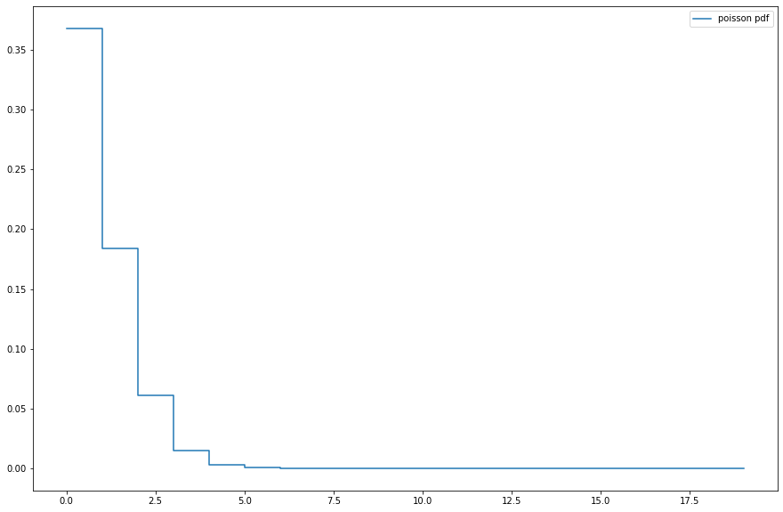

```python
from scipy.stats import poisson
import matplotlib.pyplot as plt
plt.rcParams["figure.figsize"] = (15,10)
fig, ax = plt.subplots(1, 1)
x = range(0,20)
mu = 1
prob = stats.poisson.pmf(x, mu)
ax.step(x,prob, label='poisson pdf')
ax.legend()
```

# Non-continuous distributions Q1B-(2)

Plot 2: Poisson probability density function (mu = 0.5)

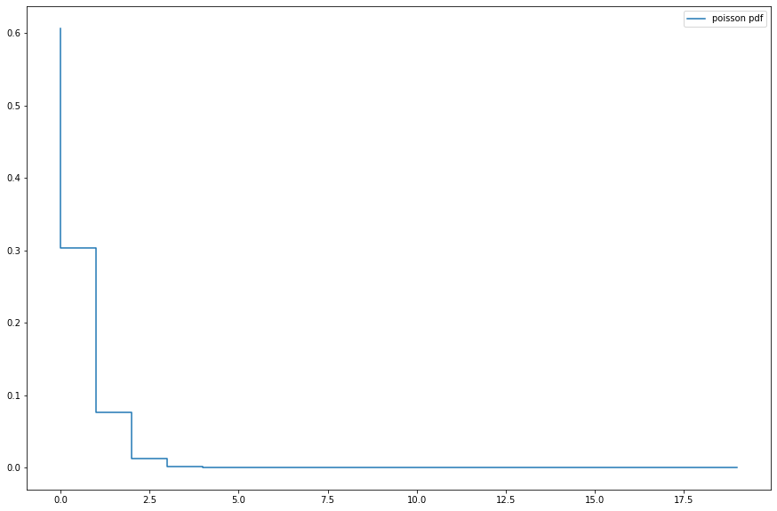

```python
plt.rcParams["figure.figsize"] = (15,10)
fig, ax = plt.subplots(1, 1)
x = range(0,20)
mu = 0.5
prob = stats.poisson.pmf(x, mu)
ax.step(x,prob, label='poisson pdf')
ax.legend()
```

# Non-continuous distributions Q1B-(3)

Plot 3: Poisson probability density function (mu = 3)

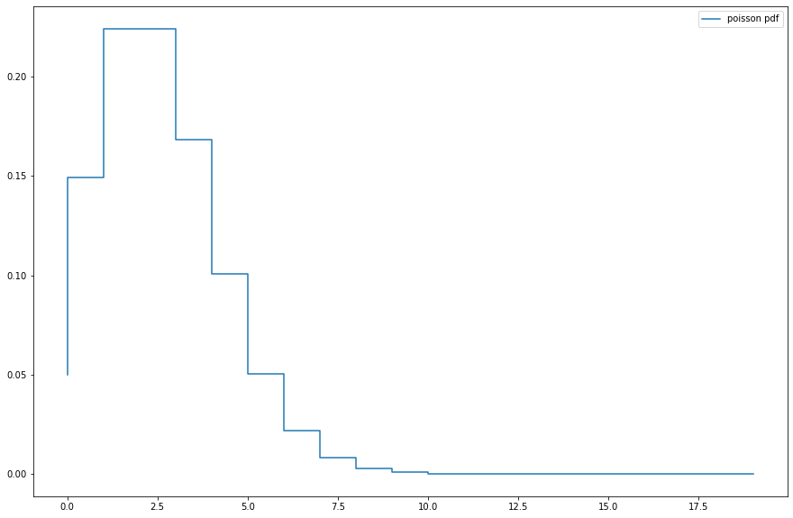

```python
plt.rcParams["figure.figsize"] = (15,10)
fig, ax = plt.subplots(1, 1)
x = range(0,20)
mu = 3
prob = stats.poisson.pmf(x, mu)
ax.step(x,prob, label='poisson pdf')
ax.legend()
```

```python
# Non-continuous distributions
```

# Non-continuous distributions Q1B: Explain the features

# Non-continuous distributions Q1C

I am setting my hypothetical value to be 4.

```python
prob1 = 1-stats.poisson.cdf(4,1)
prob2 = 1-stats.poisson.cdf(4,0.5)
prob3 = 1-stats.poisson.cdf(4,3)

print(prob1)
print(prob2)
print(prob3)
```

```
0.00365984682734366
0.00017211562995589347
0.1847367554762278
```

# Non-continuous distributions Q1D

Since the distributions, the probabilities, and the sigmas are discrete, how you evaluate the signal will have a significant impact on the result. For example, if the value of the observed signal seems to be in between 4 and 5, how you treat this value will greatly change the outcome of null hypothesis of whether that observed signal is more signal like or not.

# Non-continuous distributions Q1E

It makes sense to have a mean value of 9.2 since this is the average number of success in a given time interval. So even though the x values are discrete, the mean could be of any decimal number. However, this does not change that fact that there is only one discrete probability density associated with a dicrete x value. The mean value can change continuously depending on the possible number of sucesses, but the probability and the x values will always remain discrete for poisson distribution.